# amex_01_basemodel_xgbm_2210

### American Express - Default Prediction

- 대회 내용 : 고객이 미래의 채무 불이행 여부를 예측
- 대회 링크 : https://www.kaggle.com/competitions/amex-default-prediction

### 참조 URL 링크

- URL : https://www.kaggle.com/code/drrajkulkarni/576-tuned-xgbm

### 학습 목표

- 대용량 데이터의 처리에 대해 이해해 봅니다.
- xgboost를 활용한 기본 모델을 만들어 제출해봅니다.

### 목차

01. 라이브러리 불러오기  
02. 데이터 불러오기  
03. customer_ID의 컬럼의 라벨 인코딩을 수행 및 인덱스 지정  
04. 테스트 데이터 불러오기  
05. test 데이터 셋도 customer_ID로 라벨 인코딩  
06. 데이터 나누기 및 결측치 처리  
07. 범주형과 수치형 컬럼을 나누기  
08. 변수 구분  
09. 변수별 컬럼명 확인 및 새로운 변수 생성  
10. xgboost 모델 파라미터 설정  
11. 데이터 나누기 및 학습, 평가  
12. 혼동 행렬를 이용한 시각화  
13. 예측을 수행(1을 예측할 확률), 제출

### 대회 이해하기

- 대회 평가 : M = 0.5 * (G + D)
  - G : Normalized Gini Coefficient
  - D : 4%에서의 기본 비율(default rate)
- 평가 파일
  - customer_ID, prediction
  - ---, 0.01
  - ---, 0.22
  - ---, 0.98
  - etc.
- 주어진 데이터 셋 - 총 50.31GB
  - train_data.csv : 여러 고객의 학습용 데이터(중복되지 않는 고객 : 458913명)
  - train_labels.csv : 각각의 고객에 대한 target label(중복되지 않는 고객 : 458913명)
  - test_data.csv : 각 고객의 target label를 예측을 위한 test data(중복되지 않는 고객 : 924621명)
  - sample_submission.csv - 제출용 파일

### 01. 라이브러리 불러오기

목차로 이동하기

```python
import numpy as np
import pandas as pd
import matplotlib.pyplot as plt
import seaborn as sns

from sklearn.preprocessing import LabelEncoder,MinMaxScaler
from sklearn.model_selection import train_test_split
from sklearn.metrics import classification_report,confusion_matrix

import xgboost as xgb
from xgboost import XGBClassifier

import warnings, gc
warnings.filterwarnings("ignore")
```

### 02. 데이터 불러오기

목차로 이동하기

- parquet 형태의 데이터와 target label를 가져와 하나의 데이터로 합치기

```python
%%time

train = pd.read_parquet("../input/amex-data-integer-dtypes-parquet-format/train.parquet")
label = pd.read_csv("../input/amex-default-prediction/train_labels.csv")
train = train.merge(label,how='inner',on="customer_ID")
```

```
CPU times: user 2min, sys: 16.8 s, total: 2min 17s
Wall time: 2min 24s
```

```python
print(train.shape)
train.head(3)
```

```
(5531451, 191)
```

|  | customer_ID | S_2 | P_2 | D_39 | B_1 | B_2 | R_1 | S_3 | D_41 | B_3 | ... | D_137 | D_138 | D_139 | D_140 | D_141 | D_142 | D_143 | D_144 | D_145 | target |
| --- | --- | --- | --- | --- | --- | --- | --- | --- | --- | --- | --- | --- | --- | --- | --- | --- | --- | --- | --- | --- | --- |
| 0 | 0000099d6bd597052cdcda90ffabf56573fe9d7c79be5f... | 2017-03-09 | 0.938469 | 0 | 0.008724 | 1.006838 | 0.009228 | 0.124035 | 0.0 | 0.004709 | ... | -1 | -1 | 0 | 0 | 0.0 | NaN | 0 | 0.000610 | 0 | 0 |
| 1 | 0000099d6bd597052cdcda90ffabf56573fe9d7c79be5f... | 2017-04-07 | 0.936665 | 0 | 0.004923 | 1.000653 | 0.006151 | 0.126750 | 0.0 | 0.002714 | ... | -1 | -1 | 0 | 0 | 0.0 | NaN | 0 | 0.005492 | 0 | 0 |
| 2 | 0000099d6bd597052cdcda90ffabf56573fe9d7c79be5f... | 2017-05-28 | 0.954180 | 3 | 0.021655 | 1.009672 | 0.006815 | 0.123977 | 0.0 | 0.009423 | ... | -1 | -1 | 0 | 0 | 0.0 | NaN | 0 | 0.006986 | 0 | 0 |

3 rows × 191 columns

D_* = Delinquency variables

S_* = Spend variables

P_* = Payment variables

B_* = Balance variables

R_* = Risk variables

### 03. customer_ID의 컬럼의 라벨 인코딩을 수행 및 인덱스 지정

목차로 이동하기

```python
lab = LabelEncoder()
train['customer_ID']= lab.fit_transform(train['customer_ID'])
train['customer_ID'].head()
```

```
0    0
1    0
2    0
3    0
4    0
Name: customer_ID, dtype: int64
```

```python
%%time

train = train.groupby(['customer_ID']).tail(1).set_index('customer_ID')
```

```
CPU times: user 1.08 s, sys: 625 ms, total: 1.7 s
Wall time: 1.7 s
```

- gc.collect() : 가비지 컬렉션을 수행하여 순환참조 객체를 메모리에서 해제(메모리 확보)

```python
print( train.shape )
train.head()
gc.collect()
```

```
(458913, 190)
```

```
42
```

### 04. 테스트 데이터 불러오기

목차로 이동하기

```python
%%time

test = pd.read_parquet("../input/amex-data-integer-dtypes-parquet-format/test.parquet")
```

```
CPU times: user 12.5 s, sys: 11.6 s, total: 24.1 s
Wall time: 35.8 s
```

```python
print(test.shape)
test.head()
gc.collect()
```

```
(11363762, 190)
```

```
42
```

### 05. test 데이터 셋도 customer_ID로 라벨 인코딩

목차로 이동하기

```python
test['customer_ID']= lab.fit_transform(test['customer_ID'])
test = test.groupby(['customer_ID']).tail(1).set_index('customer_ID')
```

### 06. 데이터 나누기 및 결측치 처리

목차로 이동하기

- S_2 피처는 날짜시간 정보를 갖는 피처.

```python
X = train.drop(["target","S_2"],axis=1)
y = train.target

test = test.drop(['S_2'],axis=1)

X = X.fillna(-123)
test = test.fillna(-123)
```

```python
y.value_counts()
```

```
0    340085
1    118828
Name: target, dtype: int64
```

```python
print(X.shape, y.shape, test.shape)
gc.collect()
```

```
(458913, 188) (458913,) (924621, 188)
```

```
42
```

### 07. 범주형과 수치형 컬럼을 나누기

목차로 이동하기

```python
# 범주형 컬럼
cat_cols = ['B_30', 'B_38', 'D_63', 'D_64', 'D_66',
            'D_68', 'D_114', 'D_116', 'D_117', 'D_120', 'D_126']

# 수치형 컬럼
num_cols = [col for col in X.columns if col not in cat_cols]

all_cols = [cat_cols,num_cols]
```

```python
print(all_cols)
```

```
[['B_30', 'B_38', 'D_63', 'D_64', 'D_66', 'D_68', 'D_114', 'D_116', 'D_117', 'D_120', 'D_126'], ['P_2', 'D_39', 'B_1', 'B_2', 'R_1', 'S_3', 'D_41', 'B_3', 'D_42', 'D_43', 'D_44', 'B_4', 'D_45', 'B_5', 'R_2', 'D_46', 'D_47', 'D_48', 'D_49', 'B_6', 'B_7', 'B_8', 'D_50', 'D_51', 'B_9', 'R_3', 'D_52', '…
```

### 08. 변수 구분

목차로 이동하기

- D_* = Delinquency variables(연체 변수)
- S_* = Spend variables(지출 변수)
- P_* = Payment variables(지불 변수)
- B_* = Balance variables(균형 변수)
- R_* = Risk variables(위험 변수)

```python
D_n_cols = [col for col in num_cols if col.startswith("D")]
S_n_cols = [col for col in num_cols if col.startswith("S")]
P_n_cols = [col for col in num_cols if col.startswith("P")]
B_n_cols = [col for col in num_cols if col.startswith("B")]
R_n_cols = [col for col in num_cols if col.startswith("R")]

# 범주형 컬럼
# cat_cols = ['B_30', 'B_38', 'D_63', 'D_64', 'D_66',
#             'D_68', 'D_114', 'D_116', 'D_117', 'D_120', 'D_126']

D_c_cols = [col for col in cat_cols if col.startswith("D")]
B_c_cols = [col for col in cat_cols if col.startswith("B")]
```

### 종류별 피처의 개수

```python
print( len(D_n_cols),  len(S_n_cols), len(P_n_cols), len(B_n_cols),len(R_n_cols)  )
print( len(D_c_cols),len(B_c_cols) )
```

```
87 21 3 38 28
9 2
```

### 09. 변수별 컬럼명 확인 및 새로운 변수 생성

목차로 이동하기

- mean(평균값), min(최소값), last(각 그룹의 마지막 값)

```python
print(X.shape)
X_num_agg_D = X.groupby("customer_ID")[D_n_cols].agg(['mean','min', 'last'])
```

```
(458913, 188)
```

```python
print(X_num_agg_D.shape)
print(X_num_agg_D.columns)
```

```
(458913, 261)
MultiIndex([( 'D_39', 'mean'),
            ( 'D_39',  'min'),
            ( 'D_39', 'last'),
            ( 'D_41', 'mean'),
            ( 'D_41',  'min'),
            ( 'D_41', 'last'),
            ( 'D_42', 'mean'),
            ( 'D_42',  'min'),
            ( 'D_42', 'last'),
            ( 'D_43', 'mean'),
            ...
            ('D_142', 'last'),
            ('D_143', 'mean'),
            ('D_143',  'min'),
            ('D_143', 'last'),
            ('D_144', 'mean'),
            ('D_144',  'min'),
            ('D_144', 'last'),
            ('D_145', 'mean'),
            ('D_145',  'min'),
            ('D_145', 'last')],
           length=261)
```

```python
X_num_agg_D.columns = ['_'.join(x) for x in X_num_agg_D.columns]
print( X_num_agg_D.columns)

del X_num_agg_D
gc.collect()
```

```
Index(['D_39_mean', 'D_39_min', 'D_39_last', 'D_41_mean', 'D_41_min',
       'D_41_last', 'D_42_mean', 'D_42_min', 'D_42_last', 'D_43_mean',
       ...
       'D_142_last', 'D_143_mean', 'D_143_min', 'D_143_last', 'D_144_mean',
       'D_144_min', 'D_144_last', 'D_145_mean', 'D_145_min', 'D_145_last'],
      dtype='object', length=261)
```

```
42
```

### 각 구분별 피처 생성

```python
%%time

print('피처 엔지니어링 전', X.shape)

X_num_agg_D = X.groupby("customer_ID")[D_n_cols].agg(['mean','min', 'last'])
X_num_agg_D.columns = ['_'.join(x) for x in X_num_agg_D.columns]

X_num_agg_S = X.groupby("customer_ID")[S_n_cols].agg(['mean','min', 'last'])
X_num_agg_S.columns = ['_'.join(x) for x in X_num_agg_S.columns]

X_num_agg_P = X.groupby("customer_ID")[P_n_cols].agg(['mean','min','max' ,'last'])
X_num_agg_P.columns = ['_'.join(x) for x in X_num_agg_P.columns]

X_num_agg_B = X.groupby("customer_ID")[B_n_cols].agg(['mean','min', 'last'])
X_num_agg_B.columns = ['_'.join(x) for x in X_num_agg_B.columns]

X_num_agg_R = X.groupby("customer_ID")[R_n_cols].agg(['mean','min','last'])
X_num_agg_R.columns = ['_'.join(x) for x in X_num_agg_R.columns]

X_cat_agg_D = X.groupby("customer_ID")[D_c_cols].agg([ 'count','last','first','nunique'])
X_cat_agg_D.columns = ['_'.join(x) for x in X_cat_agg_D.columns]

X_cat_agg_B = X.groupby("customer_ID")[B_c_cols].agg([ 'count','last','nunique'])
X_cat_agg_B.columns = ['_'.join(x) for x in X_cat_agg_B.columns]

X = pd.concat([X_num_agg_D, X_num_agg_S,X_num_agg_P,X_num_agg_B,X_num_agg_R,
               X_cat_agg_D,X_cat_agg_B], axis=1)

del X_num_agg_D, X_num_agg_S,X_num_agg_P,X_num_agg_B,X_num_agg_R, X_cat_agg_D,X_cat_agg_B
_ = gc.collect()

print('피처 엔지니어링 후', X.shape)
```

```
피처 엔지니어링 전 (458913, 188)
피처 엔지니어링 후 (458913, 576)
CPU times: user 6.41 s, sys: 397 ms, total: 6.81 s
Wall time: 6.81 s
```

```python
X.head()
```

| customer_ID | D_39_mean | D_39_min | D_39_last | D_41_mean | D_41_min | D_41_last | D_42_mean | D_42_min | D_42_last | D_43_mean | ... | D_126_count | D_126_last | D_126_first | D_126_nunique | B_30_count | B_30_last | B_30_nunique | B_38_count | B_38_last | B_38_nunique |
| --- | --- | --- | --- | --- | --- | --- | --- | --- | --- | --- | --- | --- | --- | --- | --- | --- | --- | --- | --- | --- | --- |
| 0 | 0.0 | 0 | 0 | 0.0 | 0.0 | 0.0 | -123.0 | -123.0 | -123.0 | -123.000000 | ... | 1 | 2 | 2 | 1 | 1 | 0 | 1 | 1 | 2 | 1 |
| 1 | 6.0 | 6 | 6 | 0.0 | 0.0 | 0.0 | -123.0 | -123.0 | -123.0 | 0.060646 | ... | 1 | 2 | 2 | 1 | 1 | 0 | 1 | 1 | 2 | 1 |
| 2 | 0.0 | 0 | 0 | 0.0 | 0.0 | 0.0 | -123.0 | -123.0 | -123.0 | -123.000000 | ... | 1 | 2 | 2 | 1 | 1 | 0 | 1 | 1 | 1 | 1 |
| 3 | 0.0 | 0 | 0 | 0.0 | 0.0 | 0.0 | -123.0 | -123.0 | -123.0 | 0.046104 | ... | 1 | 2 | 2 | 1 | 1 | 0 | 1 | 1 | 2 | 1 |
| 4 | 0.0 | 0 | 0 | 0.0 | 0.0 | 0.0 | -123.0 | -123.0 | -123.0 | 0.044671 | ... | 1 | 2 | 2 | 1 | 1 | 0 | 1 | 1 | 1 | 1 |

5 rows × 576 columns

```python
%%time

print('피처 엔지니어링 전', test.shape)

test_num_agg_D = test.groupby("customer_ID")[D_n_cols].agg(['mean','min', 'last'])
test_num_agg_D.columns = ['_'.join(x) for x in test_num_agg_D.columns]

test_num_agg_S = test.groupby("customer_ID")[S_n_cols].agg(['mean','min', 'last'])
test_num_agg_S.columns = ['_'.join(x) for x in test_num_agg_S.columns]

test_num_agg_P = test.groupby("customer_ID")[P_n_cols].agg(['mean','min','max', 'last'])
test_num_agg_P.columns = ['_'.join(x) for x in test_num_agg_P.columns]

test_num_agg_B = test.groupby("customer_ID")[B_n_cols].agg(['mean','min', 'last'])
test_num_agg_B.columns = ['_'.join(x) for x in test_num_agg_B.columns]

test_num_agg_R = test.groupby("customer_ID")[R_n_cols].agg(['mean','min', 'last'])
test_num_agg_R.columns = ['_'.join(x) for x in test_num_agg_R.columns]

test_cat_agg_D = test.groupby("customer_ID")[D_c_cols].agg(['count','first', 'last','nunique'])
test_cat_agg_D.columns = ['_'.join(x) for x in test_cat_agg_D.columns]

test_cat_agg_B = test.groupby("customer_ID")[B_c_cols].agg([ 'count','last','nunique'])
test_cat_agg_B.columns = ['_'.join(x) for x in test_cat_agg_B.columns]

test = pd.concat([test_num_agg_D, test_num_agg_S,test_num_agg_P,test_num_agg_B,test_num_agg_R,
                  test_cat_agg_D,test_cat_agg_B], axis=1)
del test_num_agg_D, test_num_agg_S,test_num_agg_P,test_num_agg_B,test_num_agg_R,test_cat_agg_D,test_cat_agg_B

_ = gc.collect()

print('피처 엔지니어링 후', test.shape)
```

```
피처 엔지니어링 전 (924621, 188)
피처 엔지니어링 후 (924621, 576)
CPU times: user 12.7 s, sys: 704 ms, total: 13.5 s
Wall time: 13.5 s
```

### 10. xgboost 모델 파라미터 설정

목차로 이동하기

- 참조 : https://xgboost.readthedocs.io/en/stable/parameter.html

| 파라미터 이름 | 상세 설명 | 기타 |
| --- | --- | --- |
| booster | 사용할 Booster (gblinear, dart, gbtree, dart 등) | default = gbtree, 트리 기반의 모델(gbtree) gblinear(선형 모델) |
| n_estimators | 사용할 트리의 개 | ooo |
| subsample | 학습 인스턴스의 하위 샘플 비율.0.5로 설정시, XGBoost가 나무를 성장시키기 전에 학습 데이터의 절반을 무작위로 샘플링. | default=1 |
| max_depth | 나무의 최대 깊이. 깊은 트리는 메모리 소비 크다. | default=6 |
| min_child_weight | 자식에게 필요한 인스턴스 가중치의 최소 합계. min_child_weight가 클수록 알고리즘이 더 보수적 | default=1 |
| eta | 과적합을 방지하기 위해 업데이트에 사용되는 단계 크기 축소 | default=0.3 - learning_rate |
| lambda | 가중치에 대한 L2 정규화 항. 커지면 보수적. | default=1 (reg_lambda) |
| alpha | 가중치에 대한 L1 정규화 항. 커지면 보수적. | default=0 (reg_alpha) |
| gamma | 트리의 리프 노드에서 추가 파티션을 만드는데 필요한 최소 손실 감소. 클수록 더 보수적. | default=0, alias: min_split_loss |
| grow_policy | depthwise : 루틍 가장 가까운 노드에서 분할. lossguide : 손실 변화가 가장 큰 노드에서 분할. | default=depthwise |
| sample_type | 샘플링 알고리즘 타 | default='uniform' |
| normalize_type | 정규화 알고리즘의 유형 | default='tree' |
| rate_drop | 드롭아웃 비율(드롭아웃 동안 드롭할 이전 트리의 일부) | default=0.0 |
| skip_drop | 드롭아웃을 건너뛸 확률. | range[0.0, 1.0] |

```python
xgb_parms ={
     'booster': 'dart',
     'n_jobs':4,
     'n_estimators':1000,
     'lambda': 4.091409953463271e-08,
     'alpha': 3.6353429991712695e-08,
     'subsample': 0.6423675532438815,
     'colsample_bytree': 0.7830450413657872,
     'max_depth': 9,
     'min_child_weight': 5,
     'eta': 0.3749337530972536,
     'gamma': 0.0745370910451703,
     'grow_policy': 'depthwise',
     'sample_type': 'uniform',
     'normalize_type': 'tree',
     'rate_drop': 0.0723975209176045,
     'skip_drop': 0.9026367296518939}
```

### 11. 데이터 나누기 및 학습, 평가

목차로 이동하기

```python
X_train,X_valid,y_train,y_valid = train_test_split(X, y, test_size=0.25,stratify=y)
```

```python
%%time

my_model = XGBClassifier(**xgb_parms)
my_model.fit(X_train, y_train,
             early_stopping_rounds=10,
             eval_set=[(X_valid, y_valid)],
             verbose=1)
```

```
CPU times: user 30min 52s, sys: 2.95 s, total: 30min 55s
Wall time: 7min 56s
```

```
XGBClassifier(alpha=3.6353429991712695e-08, base_score=0.5, booster='dart',
              callbacks=None, colsample_bylevel=1, colsample_bynode=1,
              colsample_bytree=0.7830450413657872, early_stopping_rounds=None,
              enable_categorical=False, eta=0.3749337530972536,
              eval_metric=None, gamma=0.0745370910451703, gpu_id=-1,
              grow_policy='depthwise', importance_type=None,
              interaction_constraints='', lambda=4.091409953463271e-08,
              learning_rate=0.374933749, max_bin=256, max_cat_to_onehot=4,
              max_delta_step=0, max_depth=9, max_leaves=0, min_child_weight=5,
              missing=nan, monotone_constraints='()', n_estimators=1000,
              n_jobs=4, normalize_type='tree', num_parallel_tree=1, ...)
```

```python
pred_val = my_model.predict(X_valid)
```

```python
cf = classification_report(y_valid,pred_val)
print(cf)
```

```
              precision    recall  f1-score   support

           0       0.93      0.93      0.93     85022
           1       0.80      0.79      0.80     29707

    accuracy                           0.90    114729
   macro avg       0.86      0.86      0.86    114729
weighted avg       0.89      0.90      0.90    114729
```

### 12. 혼동 행렬를 이용한 시각화

목차로 이동하기

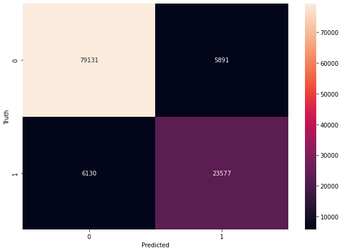

```python
cm = confusion_matrix(y_valid,pred_val)

plt.figure(figsize=(10,7))

sns.heatmap(cm,annot=True,fmt='d')

plt.xlabel('Predicted')
plt.ylabel('Truth')
```

### 13. 예측을 수행(1을 예측할 확률), 제출

목차로 이동하기

```python
pred_test = my_model.predict_proba(test)
```

```python
preds = pd.DataFrame(pred_test)
pred_final = np.array(preds[1])
pred_final
```

```
array([0.03312937, 0.00237539, 0.0565865 , ..., 0.6953294 , 0.31301746,
       0.10683217], dtype=float32)
```

```python
submission = pd.read_csv("../input/amex-default-prediction/sample_submission.csv")
```

```python
submission['prediction']=pred_final
submission
```

|  | customer_ID | prediction |
| --- | --- | --- |
| 0 | 00000469ba478561f23a92a868bd366de6f6527a684c9a... | 0.033129 |
| 1 | 00001bf2e77ff879fab36aa4fac689b9ba411dae63ae39... | 0.002375 |
| 2 | 0000210045da4f81e5f122c6bde5c2a617d03eef67f82c... | 0.056587 |
| 3 | 00003b41e58ede33b8daf61ab56d9952f17c9ad1c3976c... | 0.318178 |
| 4 | 00004b22eaeeeb0ec976890c1d9bfc14fd9427e98c4ee9... | 0.908346 |
| ... | ... | ... |
| 924616 | ffff952c631f2c911b8a2a8ca56ea6e656309a83d2f64c... | 0.025777 |
| 924617 | ffffcf5df59e5e0bba2a5ac4578a34e2b5aa64a1546cd3... | 0.715930 |
| 924618 | ffffd61f098cc056dbd7d2a21380c4804bbfe60856f475... | 0.695329 |
| 924619 | ffffddef1fc3643ea179c93245b68dca0f36941cd83977... | 0.313017 |
| 924620 | fffffa7cf7e453e1acc6a1426475d5cb9400859f82ff61... | 0.106832 |

924621 rows × 2 columns

```python
submission.to_csv("submission.csv",index=False)
```